# Analysis of Breast Cancer Dataset

Harshitha Chollangi

2024-10-14

##**Motivation and OverView**

Breast cancer is a heterogenous disease and it is the most common of all cancers which affects the women worldwide. It is one of the diseases with the highest number of cases and deaths worldwide. Breast Cancer are classified into two types Begnin and Malignant Tumours. Benign tumors have a tendency to grow at a slow pace and do not have the ability to spread. Conversely, Malignant tumors have the capability to grow rapidly, invade and destroy the surrounding healthy tissues, and metastasize to other parts of the body.

Mass and calcifications are two important features of breast cancer that are often detected through mammography or other imaging technique. A mass is a lump or thickening of breast tissue that feels different from the surrounding tissue, while calcifications are tiny mineral deposits that appear as white spots on a mammogram

Exploratory data analysis (EDA) plays a crucial role in improving the diagnosis. This process can help us to identify the type of cancer present in a patient and also determines the various attributes needed for developing a predictive model which could aid in early diagnosis and detection of cancer in patients. The predictive factors obtained through EDA can provide valuable information to guide the decision-making process for breast cancer treatment, particularly for patients at an early stage of the disease, where the tumor has not spread or grown aggressively.

##**Initial Questions** 1. What are the types of abnormalities in cancer? 2. What are the distribution of breast density in Calcification and mass case description? 3. What is the frequency of different calcification types and mass shapes? 4. What is the distribution of left and right breast images? 5. What is the distribution of subtlety scores in both calcification and mass cases? 6. What types of images are viewed in mammograms? 7. Are there any missing values in the data sets that need to be addressed before analysis? 8. Is there any correlation between features?

##**Data Description**

The most common cancer in women is breast cancer. The National Cancer Institute (NCI) has one of the most extensive cancer imaging programs. The databases also include supporting data such as patient outcomes, treatment details, and image analyses.

In this paper, the breast cancer dataset for EDA is taken from https://www.cancerimagingarchive.net/ This CBIS-DDSM (Curated Breast Imaging Subset of DDSM) is an updated and standardized version of the Digital Database for Screening Mammography (DDSM) . The DDSM is a database of 2,620 scanned film mammography studies (https://wiki.cancerimagingarchive.net/pages/viewpage.action?pageId=22516629). It contains normal, benign, and malignant cases with verified pathology information.Only clinical data is used for analysis by excluding the Mammogram images

Based on the BIRADS (Breast Imaging Reporting and Data System) category, the dataset was divided into two sections: training and testing. This division was conducted separately for all mass cases and all calcification cases. The testing set consisted of 20% of the cases, while the remaining cases were used for training.

The downloaded raw dataset is in the form of .csv files The attributes in the dataset. have both numerical and categorical values. Which includes 13 features - patient id, breast density, left or right breast, abnormality id, abnormality type, calc type, calc distribution, mass shape, mass margin, assessment, pathology, image view and subtlety.

Patient ID: Character variable that refers to a unique patient id.  
Breast density: Positive integer variable, which contains four levels of densities. Left or Right breast: Categorical variable of the patient. Abnormality type: Categorical variable, contains information based on the characteristic and appearance of mammogram Abnormality ID: Positive Integer, serves as a unique identifier for each abnormality in the dataset. Calc type: Categorical variable; each calcification type is based on an abnormality type. Calc distribution: Categorical variable, classified on the location of the breast. Mass shape: Categorical variable, based on its abnormality type. Mass margin: Categorical variable refers to the edge of a mass or lesion in the breast. Assessment: Positive integer variable, which contains five levels of assessments Pathology: Categorical variable, type of cancer. Image view : a character vector indicating the image view of the abnormality. Subtlety: Positive integer variable, on a scale from 1 to 5, based on the difficulty rating.

##**Exploratory Data analysis**

One of the primary objectives of this analysis is to create visualizations to determine which feature is most useful in distinguishing between malignant and benign tumors in breast cancer. To analyze and understand this features, dplyr package is used to create the frequency tables of breast cancer data insights.

#In this project, following are the visualizations are used using ggplot2 and treemap package **Histograms** - A histogram is used to study the distribution of one or several variables, hist() is applied to show the Frequency of breast density levels and subtlety levels in both the Calcification and mass descriptive cases

**Bar plot** - Bar plots are used to display the relationship between a numeric and a categorical variable. These plots are mostly used for comparison. Here, geom_bar() function are applied and These plot displays the count for types of abnormalities, Breast types, image views, calcification types and distributions, mass shapes and margins and pathology.

**Horizontal bar plots** - Horizontal bar plots are useful when there are many categories to display and the labels are long. They can also be used to compare the values of multiple variables. Just like vertical plots , In horizontal bar plots geom_bar() is applied for feature types of calcification case descriptionand arranged in increasing order. There are 28 unique types in calcification.

**Box plot** - are used to compare distribution of several groups using geom_boxplot() A box plot displays the median, quartiles, and outliers of the data in a simple and efficient manner.

**Density plot** - a density plot is a graphical representation of the distribution of a dataset. It shows the probability density function of the variable being plotted, which represents the likelihood of the data falling within a certain range of values. geom_density() is applied for feature assessment which consists of 5 levels and its count

**Pie chart** - A pie chart is a circular chart used to display proportional data, where each slice of the pie represents a category. geom_bar() and coord_polar() which are functions in ggplot2 are applied to features Mass shapes, Mass margins andCalcification distribution .

##**Data Analysis**

In this step we perform analysis on more than one continuous variables where the variables can be correlated with each other. Correlation analysis is a statistical technique that is used to measure the strength and direction of the relationship between two variables using cor() which is from ggcorrplot package. The values range from -1 to 1, with 1 indicating a perfect positive correlation, 0 indicating no correlation, and -1 indicating a perfect negative correlation.

**Classification Algorithm**

This step is crucial for the prediction in the dataset,Classification algorithms are a type of machine learning algorithm used for categorizing data into different classes or categories based on certain features or attributes.

**Random Forest Classification model**

.Random Forest is a powerful algorithm that can handle high-dimensional data with correlated features and can also handle missing values. In this project, Random forest algorithm is performed for Calcification Case description

The initial stage of this process consists of training to the algorithm using randomforest() from random forest package. Here , the response type is pathology and remaining features are independent variables. The subsequent stage entails utilizing the algorithm to make predictions, and finally, in the last stage, the accuracy and effectiveness of these predictions are evaluated.

After predicting values for test data set, confusion matrix is performed to know how the model is performed on the training data . It shows the number of true positives, false positives, true negatives, and false negatives for each class.

##Narrative and Summary

The Exploratory Data Analysis done on the Breast Cancer dataset helped us in visualizing various aspects needed to determine the high chance of probability in Tumour is Benign Malignant. The correlation plot showed the highest correlation between breast_density and assessment which falls on the positive number line between 1 and 0. The random forest model achieved an accuracy of 79% which is promising for predicting the pathology of breast calcification in mammogram images The model was able to identify some of the most important features for predicting malignancy, including , calcification type , calcification distribution and breast density.

#Loading Required Packages

```r
install.packages("treemap")
install.packages("randomForest")
```

```r
install.packages("rpart.plot")
install.packages("caret")
install.packages("e1071")
library(dplyr)
library(ggplot2)
library(treemap)
library(randomForest)
library(caret)
library(e1071)
library(rpart)
library(rpart.plot)
install.packages("ggcorrplot")
library(ggcorrplot)
```

## R Markdown

#Calc Case description

```r
CalcTrain <- read.csv("calc_case_description_train_set.csv",stringsAsFactors = FALSE)
CalcTest <- read.csv("calc_case_description_test_set.csv",stringsAsFactors = FALSE)
```

```r
CalcTrain <- subset(CalcTrain,select = -c(image.file.path,cropped.image.file.path,
ROI.mask.file.path))
CalcTest <- subset(CalcTest,select = -c(image.file.path,cropped.image.file.path,
ROI.mask.file.path))
```

```r
CalcTrain_Clean <- data.frame(CalcTrain)
CalcTest_Clean <- data.frame(CalcTest)

str(CalcTrain_Clean)
```

```
## 'data.frame':    1546 obs. of  11 variables:
##  $ patient_id          : chr  "P_00005" "P_00005" "P_00007" "P_00007" ...
##  $ breast.density      : int  3 3 4 4 1 1 1 1 1 1 ...
##  $ left.or.right.breast: chr  "RIGHT" "RIGHT" "LEFT" "LEFT" ...
##  $ image.view          : chr  "CC" "MLO" "CC" "MLO" ...
##  $ abnormality.id      : int  1 1 1 1 1 2 3 1 2 3 ...
##  $ abnormality.type    : chr  "calcification" "calcification" "calcification" "calcification" ...
##  $ calc.type           : chr  "AMORPHOUS" "AMORPHOUS" "PLEOMORPHIC" "PLEOMORPHIC" ...
##  $ calc.distribution   : chr  "CLUSTERED" "CLUSTERED" "LINEAR" "LINEAR" ...
##  $ assessment          : int  3 3 4 4 2 2 2 2 2 2 ...
##  $ pathology           : chr  "MALIGNANT" "MALIGNANT" "BENIGN" "BENIGN" ...
##  $ subtlety            : int  3 3 4 4 3 3 3 3 3 3 ...
```

```r
str(CalcTest_Clean)
```

```
## 'data.frame':    326 obs. of  11 variables:
##  $ patient_id          : chr  "P_00038" "P_00038" "P_00038" "P_00038" ...
##  $ breast.density      : int  2 2 2 2 2 2 1 1 2 2 ...
##  $ left.or.right.breast: chr  "LEFT" "LEFT" "RIGHT" "RIGHT" ...
##  $ image.view          : chr  "CC" "MLO" "CC" "CC" ...
##  $ abnormality.id      : int  1 1 1 2 1 2 2 2 1 1 ...
##  $ abnormality.type    : chr  "calcification" "calcification" "calcification" "calcification" ...
##  $ calc.type           : chr  "PUNCTATE-PLEOMORPHIC" "PUNCTATE-PLEOMORPHIC" "VASCULAR" "VASCULAR" ...
##  $ calc.distribution   : chr  "CLUSTERED" "CLUSTERED" NA NA ...
##  $ assessment          : int  4 4 2 2 2 2 2 2 2 2 ...
##  $ pathology           : chr  "BENIGN" "BENIGN" "BENIGN_WITHOUT_CALLBACK" "BENIGN_WITHOUT_CALLBACK" ...
##  $ subtlety            : int  2 2 5 5 5 5 5 5 3 3 ...
```

#Renaming columns

```r
CalcTrain_Clean <- CalcTrain_Clean %>% rename(breast_density = breast.density,
                                              left_or_right_breast = left.or.right.breast,
                                              image_view = image.view, abnormality_type = abnormality.type, abnormality_id = abnormality.id,
                                              calc_type = calc.type, calc_distribution = calc.distribution)

CalcTest_Clean <- CalcTest_Clean %>% rename(breast_density = breast.density,
                                            left_or_right_breast = left.or.right.breast,
                                            image_view = image.view, abnormality_type = abnormality.type, abnormality_id = abnormality.id,
                                            calc_type = calc.type, calc_distribution = calc.distribution)
```

#Checking missing values

```r
getmode <- function(v) {
  uniqv <- unique(v)
  uniqv[which.max(tabulate(match(v, uniqv)))]
}
```

```r
colSums(is.na(CalcTrain_Clean))
```

```
##           patient_id       breast_density left_or_right_breast
##                    0                    0                    0
##           image_view       abnormality_id     abnormality_type
##                    0                    0                    0
##            calc_type    calc_distribution           assessment
##                   20                  376                    0
##            pathology             subtlety
##                    0                    0
```

```r
CalcTrain_Clean$calc_distribution[is.na(CalcTrain_Clean$calc_distribution)] <- getmode(CalcTrain_Clean$calc_distribution)
CalcTrain_Clean$calc_type[is.na(CalcTrain_Clean$calc_type)] <- getmode(CalcTrain_Clean$calc_type)
na.omit(CalcTrain_Clean)
```

[output not shown]

[output cut: 4626 more lines]

```r
colSums(is.na(CalcTrain_Clean))
```

```
##           patient_id       breast_density left_or_right_breast
##                    0                    0                    0
##           image_view       abnormality_id     abnormality_type
##                    0                    0                    0
##            calc_type    calc_distribution           assessment
##                    0                    0                    0
##            pathology             subtlety
##                    0                    0
```

```r
colSums(is.na(CalcTest_Clean))
```

```
##           patient_id       breast_density left_or_right_breast
##                    0                    0                    0
##           image_view       abnormality_id     abnormality_type
##                    0                    0                    0
##            calc_type    calc_distribution           assessment
##                    4                   63                    0
##            pathology             subtlety
##                    0                    0
```

```r
CalcTest_Clean$calc_distribution[is.na(CalcTest_Clean$calc_distribution)] <- getmode(CalcTest_Clean$calc_distribution)
CalcTest_Clean$calc_type[is.na(CalcTest_Clean$calc_type)] <- getmode(CalcTest_Clean$calc_type)
na.omit(CalcTest_Clean)
```

[output not shown]

[output cut: 966 more lines]

```r
colSums(is.na(CalcTest_Clean))
```

```
##           patient_id       breast_density left_or_right_breast
##                    0                    0                    0
##           image_view       abnormality_id     abnormality_type
##                    0                    0                    0
##            calc_type    calc_distribution           assessment
##                    0                    0                    0
##            pathology             subtlety
##                    0                    0
```

#Summary Statistics

```r
summary(CalcTrain_Clean)
```

```
##   patient_id        breast_density  left_or_right_breast  image_view
##  Length:1546        Min.   :1.000   Length:1546          Length:1546
##  Class :character   1st Qu.:2.000   Class :character     Class :character
##  Mode  :character   Median :3.000   Mode  :character     Mode  :character
##                     Mean   :2.664
##                     3rd Qu.:3.000
##                     Max.   :4.000
##  abnormality_id  abnormality_type    calc_type         calc_distribution
##  Min.   :1.000   Length:1546        Length:1546        Length:1546
##  1st Qu.:1.000   Class :character   Class :character   Class :character
##  Median :1.000   Mode  :character   Mode  :character   Mode  :character
##  Mean   :1.415
##  3rd Qu.:1.000
##  Max.   :7.000
##    assessment     pathology            subtlety
##  Min.   :0.000   Length:1546        Min.   :1.000
##  1st Qu.:2.000   Class :character   1st Qu.:3.000
##  Median :4.000   Mode  :character   Median :3.000
##  Mean   :3.259                      Mean   :3.411
##  3rd Qu.:4.000                      3rd Qu.:4.000
##  Max.   :5.000                      Max.   :5.000
```

```r
summary(CalcTest_Clean)
```

```
##   patient_id        breast_density  left_or_right_breast  image_view
##  Length:326         Min.   :0.000   Length:326           Length:326
##  Class :character   1st Qu.:2.000   Class :character     Class :character
##  Mode  :character   Median :3.000   Mode  :character     Mode  :character
##                     Mean   :2.696
##                     3rd Qu.:3.000
##                     Max.   :4.000
##  abnormality_id  abnormality_type    calc_type         calc_distribution
##  Min.   :1.000   Length:326         Length:326         Length:326
##  1st Qu.:1.000   Class :character   Class :character   Class :character
##  Median :1.000   Mode  :character   Mode  :character   Mode  :character
##  Mean   :1.215
##  3rd Qu.:1.000
##  Max.   :5.000
##    assessment     pathology            subtlety
##  Min.   :0.000   Length:326         Min.   :1.000
##  1st Qu.:2.000   Class :character   1st Qu.:3.000
##  Median :4.000   Mode  :character   Median :3.000
##  Mean   :3.454                      Mean   :3.319
##  3rd Qu.:4.000                      3rd Qu.:4.000
##  Max.   :5.000                      Max.   :5.000
```

#Setting Categorical variables

```r
CalcTrain_Clean$left_or_right_breast <- factor(CalcTrain_Clean$left_or_right_breast)
CalcTrain_Clean$image_view <- factor(CalcTrain_Clean$image_view)
CalcTrain_Clean$abnormality_type <- factor(CalcTrain_Clean$abnormality_type)
CalcTrain_Clean$calc_type <- factor(CalcTrain_Clean$calc_type)
CalcTrain_Clean$calc_distribution <- factor(CalcTrain_Clean$calc_distribution)
CalcTrain_Clean$pathology <- factor(CalcTrain_Clean$pathology)
```

```r
CalcTest_Clean$left_or_right_breast <- factor(CalcTest_Clean$left_or_right_breast)
CalcTest_Clean$image_view <- factor(CalcTest_Clean$image_view )
CalcTest_Clean$abnormality_type <- factor(CalcTest_Clean$abnormality_type)
CalcTest_Clean$calc_type <- factor(CalcTest_Clean$calc_type)
CalcTest_Clean$calc_distribution <- factor(CalcTest_Clean$calc_distribution)
CalcTest_Clean$pathology <- factor(CalcTest_Clean$pathology)
```

```r
head(CalcTrain_Clean)
```

```
##   patient_id breast_density left_or_right_breast image_view abnormality_id
## 1    P_00005              3                RIGHT         CC              1
## 2    P_00005              3                RIGHT        MLO              1
## 3    P_00007              4                 LEFT         CC              1
## 4    P_00007              4                 LEFT        MLO              1
## 5    P_00008              1                 LEFT         CC              1
## 6    P_00008              1                 LEFT         CC              2
##   abnormality_type   calc_type calc_distribution assessment
## 1    calcification   AMORPHOUS         CLUSTERED          3
## 2    calcification   AMORPHOUS         CLUSTERED          3
## 3    calcification PLEOMORPHIC            LINEAR          4
## 4    calcification PLEOMORPHIC            LINEAR          4
## 5    calcification PLEOMORPHIC          REGIONAL          2
## 6    calcification PLEOMORPHIC          REGIONAL          2
##                 pathology subtlety
## 1               MALIGNANT        3
## 2               MALIGNANT        3
## 3                  BENIGN        4
## 4                  BENIGN        4
## 5 BENIGN_WITHOUT_CALLBACK        3
## 6 BENIGN_WITHOUT_CALLBACK        3
```

```r
head(CalcTest_Clean)
```

```
##   patient_id breast_density left_or_right_breast image_view abnormality_id
## 1    P_00038              2                 LEFT         CC              1
## 2    P_00038              2                 LEFT        MLO              1
## 3    P_00038              2                RIGHT         CC              1
## 4    P_00038              2                RIGHT         CC              2
## 5    P_00038              2                RIGHT        MLO              1
## 6    P_00038              2                RIGHT        MLO              2
##   abnormality_type            calc_type calc_distribution assessment
## 1    calcification PUNCTATE-PLEOMORPHIC         CLUSTERED          4
## 2    calcification PUNCTATE-PLEOMORPHIC         CLUSTERED          4
## 3    calcification             VASCULAR         CLUSTERED          2
## 4    calcification             VASCULAR         CLUSTERED          2
## 5    calcification             VASCULAR         CLUSTERED          2
## 6    calcification             VASCULAR         CLUSTERED          2
##                 pathology subtlety
## 1                  BENIGN        2
## 2                  BENIGN        2
## 3 BENIGN_WITHOUT_CALLBACK        5
## 4 BENIGN_WITHOUT_CALLBACK        5
## 5 BENIGN_WITHOUT_CALLBACK        5
## 6 BENIGN_WITHOUT_CALLBACK        5
```

##Mass Case Description

```r
MassTrain <- read.csv("mass_case_description_train_set.csv",stringsAsFactors = FALSE)
MassTest <- read.csv("mass_case_description_test_set.csv",stringsAsFactors = FALSE)
```

```r
MassTrain <- subset(MassTrain,select = -c(image.file.path,cropped.image.file.path,
ROI.mask.file.path))

MassTest <- subset(MassTest,select = -c(image.file.path,cropped.image.file.path,
ROI.mask.file.path))
```

```r
MassTrain_Clean <- data.frame(MassTrain)
MassTest_Clean <- data.frame(MassTest)

str(MassTrain_Clean)
```

```
## 'data.frame':    1318 obs. of  11 variables:
##  $ patient_id          : chr  "P_00001" "P_00001" "P_00004" "P_00004" ...
##  $ breast_density      : int  3 3 3 3 3 3 3 3 2 2 ...
##  $ left.or.right.breast: chr  "LEFT" "LEFT" "LEFT" "LEFT" ...
##  $ image.view          : chr  "CC" "MLO" "CC" "MLO" ...
##  $ abnormality.id      : int  1 1 1 1 1 1 1 1 1 1 ...
##  $ abnormality.type    : chr  "mass" "mass" "mass" "mass" ...
##  $ mass.shape          : chr  "IRREGULAR-ARCHITECTURAL_DISTORTION" "IRREGULAR-ARCHITECTURAL_DISTORTION" "ARCHITECTURAL_DISTORTION" "ARCHITECTURAL_DISTORTION" ...
##  $ mass.margins        : chr  "SPICULATED" "SPICULATED" "ILL_DEFINED" "ILL_DEFINED" ...
##  $ assessment          : int  4 4 4 4 4 4 4 4 4 4 ...
##  $ pathology           : chr  "MALIGNANT" "MALIGNANT" "BENIGN" "BENIGN" ...
##  $ subtlety            : int  4 4 3 3 5 4 4 4 5 5 ...
```

```r
str(MassTrain_Clean)
```

```
## 'data.frame':    1318 obs. of  11 variables:
##  $ patient_id          : chr  "P_00001" "P_00001" "P_00004" "P_00004" ...
##  $ breast_density      : int  3 3 3 3 3 3 3 3 2 2 ...
##  $ left.or.right.breast: chr  "LEFT" "LEFT" "LEFT" "LEFT" ...
##  $ image.view          : chr  "CC" "MLO" "CC" "MLO" ...
##  $ abnormality.id      : int  1 1 1 1 1 1 1 1 1 1 ...
##  $ abnormality.type    : chr  "mass" "mass" "mass" "mass" ...
##  $ mass.shape          : chr  "IRREGULAR-ARCHITECTURAL_DISTORTION" "IRREGULAR-ARCHITECTURAL_DISTORTION" "ARCHITECTURAL_DISTORTION" "ARCHITECTURAL_DISTORTION" ...
##  $ mass.margins        : chr  "SPICULATED" "SPICULATED" "ILL_DEFINED" "ILL_DEFINED" ...
##  $ assessment          : int  4 4 4 4 4 4 4 4 4 4 ...
##  $ pathology           : chr  "MALIGNANT" "MALIGNANT" "BENIGN" "BENIGN" ...
##  $ subtlety            : int  4 4 3 3 5 4 4 4 5 5 ...
```

```r
MassTrain_Clean <- MassTrain_Clean %>% rename( left_or_right_breast = left.or.right.breast,
                                              image_view = image.view, abnormality_id=abnormality.id, abnormality_type = abnormality.type,
                                              mass_Shape = mass.shape, mass_margins = mass.margins)

MassTest_Clean <- MassTest_Clean %>% rename( left_or_right_breast = left.or.right.breast,
                                              image_view = image.view, abnormality_id=abnormality.id, abnormality_type = abnormality.type,
                                              mass_Shape = mass.shape, mass_margins = mass.margins)
```

#Checking null values for Mass case

```r
colSums(is.na(MassTrain_Clean))
```

```
##           patient_id       breast_density left_or_right_breast
##                    0                    0                    0
##           image_view       abnormality_id     abnormality_type
##                    0                    0                    0
##           mass_Shape         mass_margins           assessment
##                    4                   43                    0
##            pathology             subtlety
##                    0                    0
```

```r
MassTrain_Clean$mass_Shape[is.na(MassTrain_Clean$mass_Shape)] <- getmode(MassTrain_Clean$mass_Shape)

MassTrain_Clean$mass_margins[is.na(MassTrain_Clean$mass_margins)] <- getmode(MassTrain_Clean$mass_margins)
na.omit(MassTrain_Clean)
```

[output not shown]

[output cut: 5261 more lines]

```r
colSums(is.na(MassTrain_Clean))
```

```
##           patient_id       breast_density left_or_right_breast
##                    0                    0                    0
##           image_view       abnormality_id     abnormality_type
##                    0                    0                    0
##           mass_Shape         mass_margins           assessment
##                    0                    0                    0
##            pathology             subtlety
##                    0                    0
```

```r
colSums(is.na(MassTest_Clean))
```

```
##           patient_id       breast_density left_or_right_breast
##                    0                    0                    0
##           image_view       abnormality_id     abnormality_type
##                    0                    0                    0
##           mass_Shape         mass_margins           assessment
##                    0                   17                    0
##            pathology             subtlety
##                    0                    0
```

```r
MassTest_Clean$mass_margins[is.na(MassTest_Clean$mass_margins)] <- getmode(MassTest_Clean$mass_margins)
na.omit(MassTest_Clean)
```

[output not shown]

[output cut: 1501 more lines]

```r
colSums(is.na(MassTest_Clean))
```

```
##           patient_id       breast_density left_or_right_breast
##                    0                    0                    0
##           image_view       abnormality_id     abnormality_type
##                    0                    0                    0
##           mass_Shape         mass_margins           assessment
##                    0                    0                    0
##            pathology             subtlety
##                    0                    0
```

```r
summary(MassTrain_Clean)
```

```
##   patient_id        breast_density  left_or_right_breast  image_view
##  Length:1318        Min.   :1.000   Length:1318          Length:1318
##  Class :character   1st Qu.:2.000   Class :character     Class :character
##  Mode  :character   Median :2.000   Mode  :character     Mode  :character
##                     Mean   :2.203
##                     3rd Qu.:3.000
##                     Max.   :4.000
##  abnormality_id  abnormality_type    mass_Shape        mass_margins
##  Min.   :1.000   Length:1318        Length:1318        Length:1318
##  1st Qu.:1.000   Class :character   Class :character   Class :character
##  Median :1.000   Mode  :character   Mode  :character   Mode  :character
##  Mean   :1.116
##  3rd Qu.:1.000
##  Max.   :6.000
##    assessment     pathology            subtlety
##  Min.   :0.000   Length:1318        Min.   :0.000
##  1st Qu.:3.000   Class :character   1st Qu.:3.000
##  Median :4.000   Mode  :character   Median :4.000
##  Mean   :3.505                      Mean   :3.966
##  3rd Qu.:4.000                      3rd Qu.:5.000
##  Max.   :5.000                      Max.   :5.000
```

```r
summary(MassTest_Clean)
```

```
##   patient_id        breast_density  left_or_right_breast  image_view
##  Length:378         Min.   :1.000   Length:378           Length:378
##  Class :character   1st Qu.:2.000   Class :character     Class :character
##  Mode  :character   Median :2.000   Mode  :character     Mode  :character
##                     Mean   :2.397
##                     3rd Qu.:3.000
##                     Max.   :4.000
##  abnormality_id  abnormality_type    mass_Shape        mass_margins
##  Min.   :1.000   Length:378         Length:378         Length:378
##  1st Qu.:1.000   Class :character   Class :character   Class :character
##  Median :1.000   Mode  :character   Mode  :character   Mode  :character
##  Mean   :1.093
##  3rd Qu.:1.000
##  Max.   :4.000
##    assessment     pathology            subtlety
##  Min.   :0.000   Length:378         Min.   :1.000
##  1st Qu.:3.000   Class :character   1st Qu.:3.000
##  Median :4.000   Mode  :character   Median :4.000
##  Mean   :3.534                      Mean   :3.786
##  3rd Qu.:4.000                      3rd Qu.:5.000
##  Max.   :5.000                      Max.   :5.000
```

```r
MassTrain_Clean$image_view <- factor(MassTrain_Clean$image_view)
MassTrain_Clean$left_or_right_breast <- factor(MassTrain_Clean$left_or_right_breast)
MassTrain_Clean$abnormality_type <- factor(MassTrain_Clean$abnormality_type)
MassTrain_Clean$mass_margins <- factor(MassTrain_Clean$mass_margins)
MassTrain_Clean$mass_Shape <- factor(MassTrain_Clean$mass_Shape)
```

```r
MassTest_Clean$image_view <- factor(MassTest_Clean$image_view)
MassTest_Clean$left_or_right_breast <- factor(MassTest_Clean$left_or_right_breast)
MassTest_Clean$abnormality_type <- factor(MassTest_Clean$abnormality_type)
MassTest_Clean$mass_margins <- factor(MassTest_Clean$mass_margins)
MassTest_Clean$mass_Shape <- factor(MassTest_Clean$mass_Shape)
```

```r
head(MassTrain_Clean)
```

```
##   patient_id breast_density left_or_right_breast image_view abnormality_id
## 1    P_00001              3                 LEFT         CC              1
## 2    P_00001              3                 LEFT        MLO              1
## 3    P_00004              3                 LEFT         CC              1
## 4    P_00004              3                 LEFT        MLO              1
## 5    P_00004              3                RIGHT        MLO              1
## 6    P_00009              3                RIGHT         CC              1
##   abnormality_type                         mass_Shape  mass_margins assessment
## 1             mass IRREGULAR-ARCHITECTURAL_DISTORTION    SPICULATED          4
## 2             mass IRREGULAR-ARCHITECTURAL_DISTORTION    SPICULATED          4
## 3             mass           ARCHITECTURAL_DISTORTION   ILL_DEFINED          4
## 4             mass           ARCHITECTURAL_DISTORTION   ILL_DEFINED          4
## 5             mass                               OVAL CIRCUMSCRIBED          4
## 6             mass                               OVAL   ILL_DEFINED          4
##   pathology subtlety
## 1 MALIGNANT        4
## 2 MALIGNANT        4
## 3    BENIGN        3
## 4    BENIGN        3
## 5    BENIGN        5
## 6 MALIGNANT        4
```

```r
head(MassTest_Clean)
```

```
##   patient_id breast_density left_or_right_breast image_view abnormality_id
## 1    P_00016              4                 LEFT         CC              1
## 2    P_00016              4                 LEFT        MLO              1
## 3    P_00017              2                 LEFT         CC              1
## 4    P_00017              2                 LEFT        MLO              1
## 5    P_00032              3                RIGHT         CC              1
## 6    P_00032              3                RIGHT        MLO              1
##   abnormality_type mass_Shape  mass_margins assessment pathology subtlety
## 1             mass  IRREGULAR    SPICULATED          5 MALIGNANT        5
## 2             mass  IRREGULAR    SPICULATED          5 MALIGNANT        5
## 3             mass      ROUND CIRCUMSCRIBED          4 MALIGNANT        4
## 4             mass      ROUND   ILL_DEFINED          4 MALIGNANT        4
## 5             mass      ROUND      OBSCURED          0    BENIGN        2
## 6             mass      ROUND      OBSCURED          0    BENIGN        2
```

##Data Exploration #1. number of abnormalities in calc and mass

```r
data_insight_1 <- data.frame(
  abnormality = c(CalcTrain_Clean$abnormality_type[1], MassTrain_Clean$abnormality_type[1]),
  counts_of_abnormalities = c(nrow(CalcTrain_Clean), nrow(MassTrain_Clean))
)
```

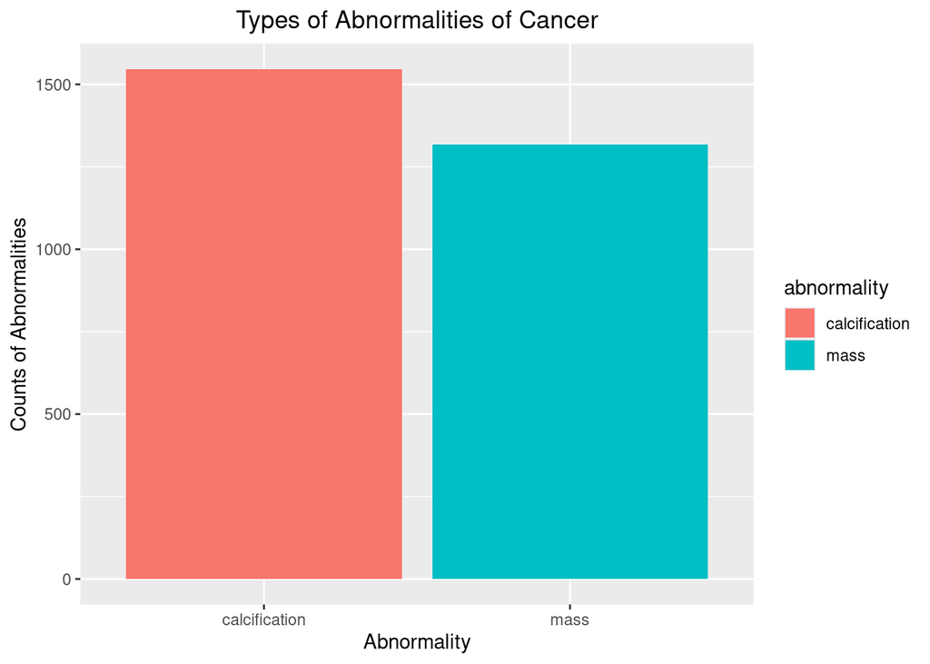

```r
ggplot(data_insight_1, aes(x = abnormality, y = counts_of_abnormalities, fill = abnormality)) +
  geom_bar(stat = "identity") +
  labs(x = "Abnormality", y = "Counts of Abnormalities", title = "Types of Abnormalities of Cancer") +
  theme(plot.title = element_text(hjust = 0.5))
```

#2.Count of left and right breast in Calcification

```r
LR_breast <- data.frame(table(CalcTrain_Clean$left_or_right_breast)) %>%
  setNames(c("Breast", "Count"))
LR_breast
```

```
##   Breast Count
## 1   LEFT   818
## 2  RIGHT   728
```

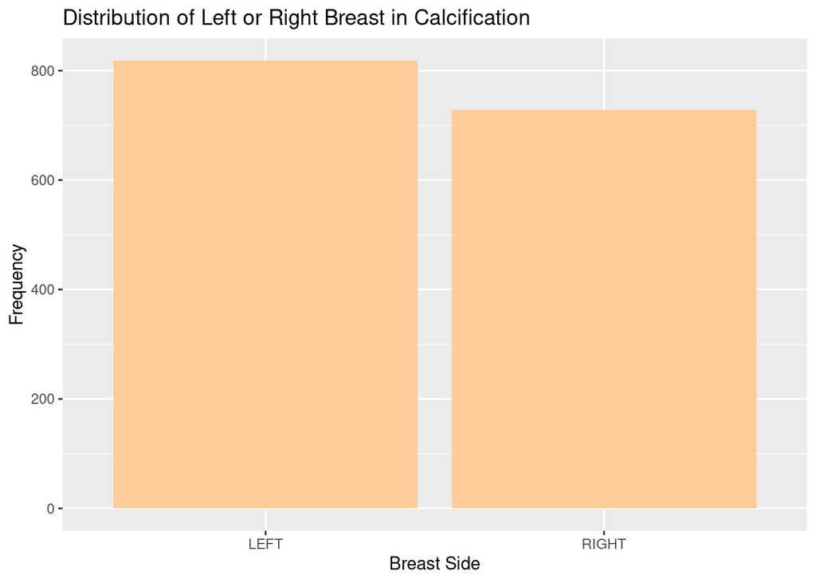

```r
 ggplot(CalcTrain_Clean, aes(x = left_or_right_breast)) +
  geom_bar(fill = "#FFCC99") +
  labs(title = "Distribution of Left or Right Breast in Calcification") +
  xlab("Breast Side") +
  ylab("Frequency")
```

#Count of left and right breast in Mass Description

```r
LR_breastM <- data.frame(table(MassTrain_Clean$left_or_right_breast)) %>%
  setNames(c("Breast", "Count"))
LR_breastM
```

```
##   Breast Count
## 1   LEFT   631
## 2  RIGHT   687
```

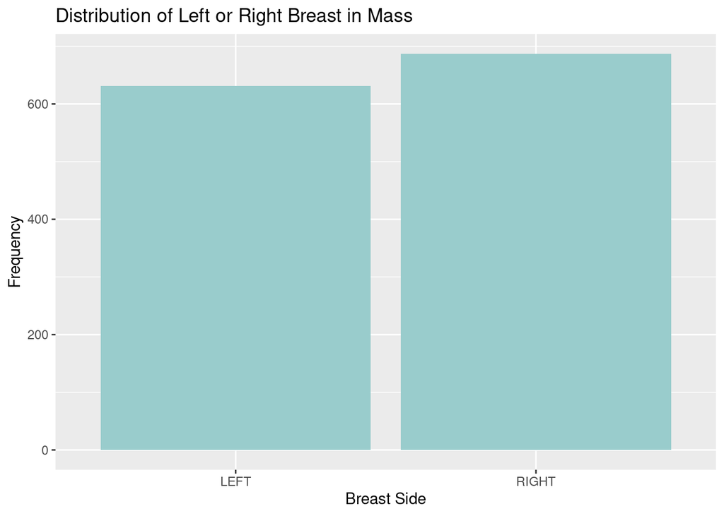

```r
 ggplot(MassTrain_Clean, aes(x = left_or_right_breast)) +
  geom_bar(fill = "#99CCCC") +
  labs(title = "Distribution of Left or Right Breast in Mass") +
  xlab("Breast Side") +
  ylab("Frequency")
```

#3.Types of Calcification Cancer

```r
calc_type_count <- CalcTrain_Clean %>%
  group_by(calc_type) %>%
  summarize(count = n()) %>%
  mutate(calc_type = if_else(count < 5, "Other", calc_type)) %>%
  group_by(calc_type) %>%
  summarize(count = sum(count))
```

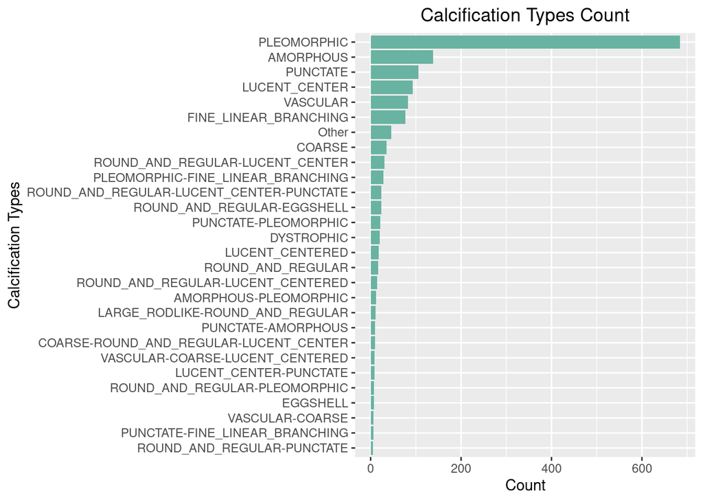

```r
ggplot(calc_type_count, aes(x = count, y = reorder(calc_type, count))) +
  geom_bar(stat = "identity", fill = "#69b3a2") +
  labs(x = "Count", y = "Calcification Types") +
  ggtitle("Calcification Types Count") +
  theme(plot.title = element_text(hjust = 0.5))
```

#Types of Mass shapes

```r
Mass.Shape <- data.frame(table(MassTrain_Clean$mass_Shape)) %>%
  setNames(c("Mass_Shape", "Count"))
Mass.Shape
```

```
##                                  Mass_Shape Count
## 1                  ARCHITECTURAL_DISTORTION    80
## 2                  ASYMMETRIC_BREAST_TISSUE    20
## 3                  FOCAL_ASYMMETRIC_DENSITY    19
## 4                                 IRREGULAR   355
## 5        IRREGULAR-ARCHITECTURAL_DISTORTION    45
## 6        IRREGULAR-FOCAL_ASYMMETRIC_DENSITY     2
## 7                                 LOBULATED   305
## 8        LOBULATED-ARCHITECTURAL_DISTORTION     2
## 9                       LOBULATED-IRREGULAR     5
## 10                     LOBULATED-LYMPH_NODE     3
## 11                           LOBULATED-OVAL     1
## 12                               LYMPH_NODE    26
## 13                                     OVAL   321
## 14                          OVAL-LYMPH_NODE     6
## 15                                    ROUND   123
## 16 ROUND-IRREGULAR-ARCHITECTURAL_DISTORTION     1
## 17                          ROUND-LOBULATED     1
## 18                               ROUND-OVAL     3
```

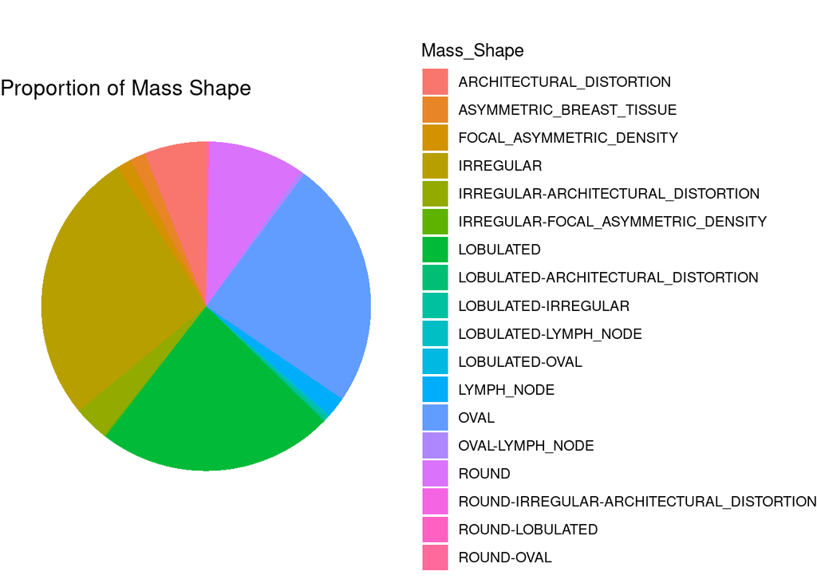

```r
ggplot(Mass.Shape, aes(x = "", y = Count , fill = Mass_Shape)) +
  geom_bar(stat = "identity", width = 1) +
  coord_polar("y", start = 0) +
  labs(title = "Proportion of Mass Shape") +
  theme_void() +
  theme(legend.position = "right")
```

#4.Types of Calc distributions

```r
CalcDist <- data.frame(table(CalcTrain_Clean$calc_distribution)) %>%
 setNames(c("calc_distribution", "calc_dist_counts"))
CalcDist
```

```
##     calc_distribution calc_dist_counts
## 1           CLUSTERED             1116
## 2    CLUSTERED-LINEAR               25
## 3 CLUSTERED-SEGMENTAL                5
## 4 DIFFUSELY_SCATTERED               37
## 5              LINEAR               90
## 6    LINEAR-SEGMENTAL                5
## 7            REGIONAL               99
## 8   REGIONAL-REGIONAL                1
## 9           SEGMENTAL              168
```

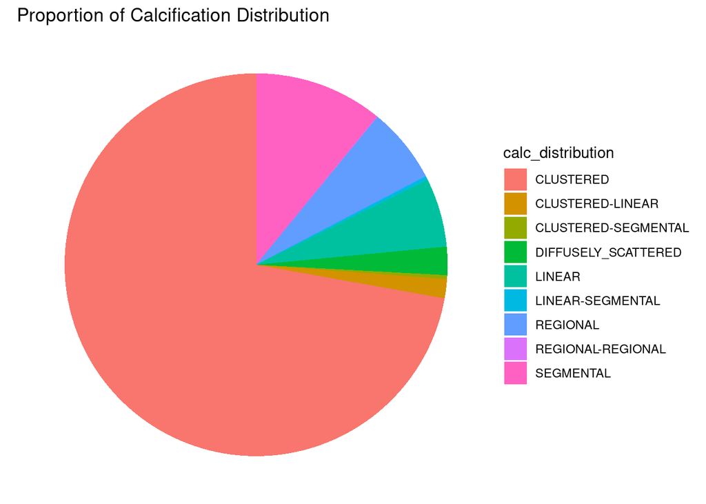

```r
ggplot(CalcDist, aes(x = "", y = calc_dist_counts, fill = calc_distribution)) +
  geom_bar(stat = "identity", width = 1) +
  coord_polar("y", start = 0) +
  labs(title = "Proportion of Calcification Distribution") +
  theme_void() +
  theme(legend.position = "right")
```

#Types of Mass Margins

```r
Mass.Margins <- data.frame(table(MassTrain_Clean$mass_margins)) %>%
                 setNames(c("mass_margins", "counts"))
Mass.Margins
```

```
##                             mass_margins counts
## 1                          CIRCUMSCRIBED    348
## 2              CIRCUMSCRIBED-ILL_DEFINED     27
## 3           CIRCUMSCRIBED-MICROLOBULATED      1
## 4                 CIRCUMSCRIBED-OBSCURED     19
## 5                            ILL_DEFINED    278
## 6                 ILL_DEFINED-SPICULATED     25
## 7                         MICROLOBULATED    108
## 8             MICROLOBULATED-ILL_DEFINED      3
## 9  MICROLOBULATED-ILL_DEFINED-SPICULATED      2
## 10             MICROLOBULATED-SPICULATED      2
## 11                              OBSCURED    197
## 12                  OBSCURED-ILL_DEFINED     19
## 13       OBSCURED-ILL_DEFINED-SPICULATED      4
## 14                   OBSCURED-SPICULATED      4
## 15                            SPICULATED    281
```

[figure not shown]

```r
ggplot(Mass.Margins, aes(x = "", y = counts, fill = mass_margins)) +
  geom_bar(stat = "identity", width = 1) +
  coord_polar("y", start = 0) +
  labs(title = "Proportion of Calcification Distribution") +
  theme_void() +
  theme(legend.position = "right")
```

#5.Levels of Breast Density

```r
breastdensity_Calc <- data.frame(table(CalcTrain_Clean$breast_density)) %>%
                 setNames(c("levels", "counts"))

breastdensity_Calc
```

```
##   levels counts
## 1      1    175
## 2      2    501
## 3      3    539
## 4      4    331
```

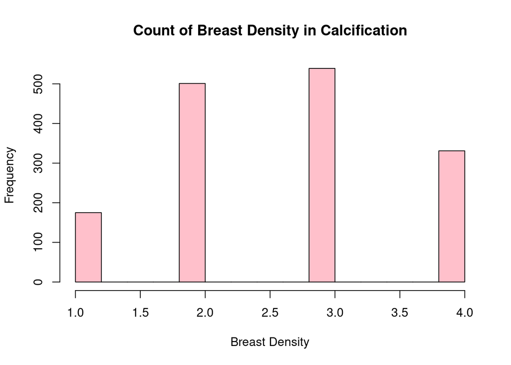

```r
hist(CalcTrain_Clean$breast_density,
     main = "Count of Breast Density in Calcification",
     xlab = "Breast Density",
     col = "pink")
```

# Distribution of Calcification Breast Density by Pathology in Calcification

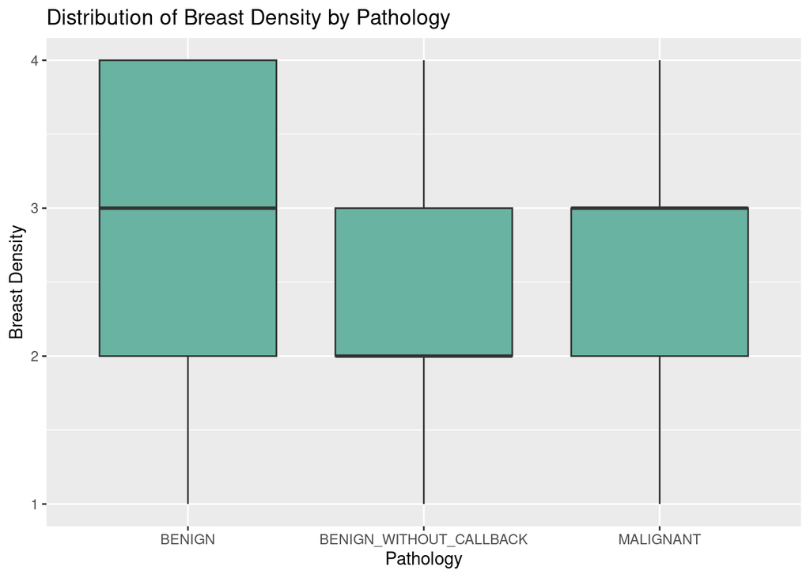

```r
ggplot(CalcTrain_Clean, aes(x = pathology, y = breast_density)) +
  geom_boxplot(fill = "#69b3a2") +
  labs(x = "Pathology", y = "Breast Density",
       title = "Distribution of Breast Density by Pathology")
```

#Levels of Breast density in Mass

```r
breastdensity_Mass <-  data.frame(table(MassTrain_Clean$breast_density)) %>%
                 setNames(c("levels", "counts"))
breastdensity_Mass
```

```
##   levels counts
## 1      1    287
## 2      2    585
## 3      3    337
## 4      4    109
```

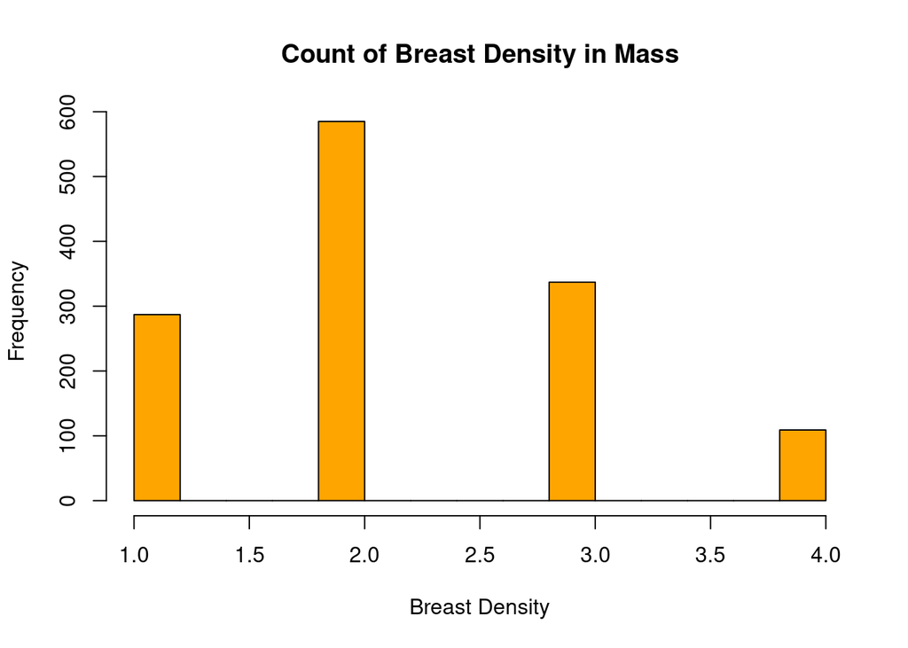

```r
hist(MassTrain_Clean$breast_density,
     main = "Count of Breast Density in Mass",
     xlab = "Breast Density",
     col = "orange")
```

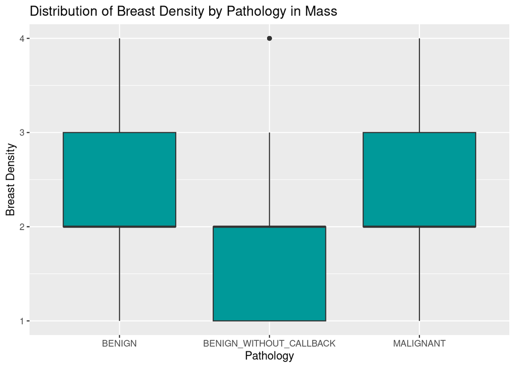

```r
ggplot(MassTrain_Clean, aes(x = pathology, y = breast_density)) +
  geom_boxplot(fill = "#009999") +
  labs(x = "Pathology", y = "Breast Density",
       title = "Distribution of Breast Density by Pathology in Mass")
```

#6.Assessments in Calcification case

```r
Assessment_Calc<- data.frame(table(CalcTrain_Clean$assessment)) %>%
setNames(c("levels", "counts"))
Assessment_Calc
```

```
##   levels counts
## 1      0     63
## 2      2    482
## 3      3     89
## 4      4    753
## 5      5    159
```

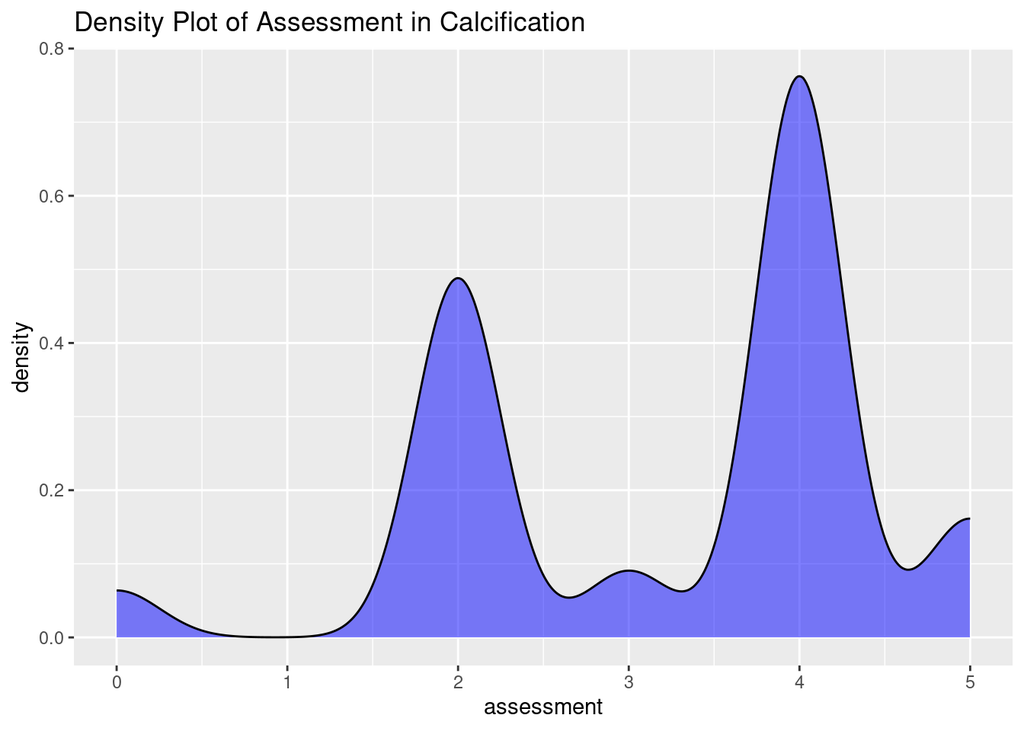

```r
ggplot(data = CalcTrain_Clean, aes(x = assessment)) +
  geom_density(fill = "blue", alpha = 0.5) +
  ggtitle("Density Plot of Assessment in Calcification")
```

#Assessment in Mass Description

```r
Assessment_Mass <- data.frame(table(MassTrain_Clean$assessment)) %>%
setNames(c("levels", "counts"))
Assessment_Mass
```

```
##   levels counts
## 1      0    129
## 2      1      1
## 3      2     77
## 4      3    279
## 5      4    533
## 6      5    299
```

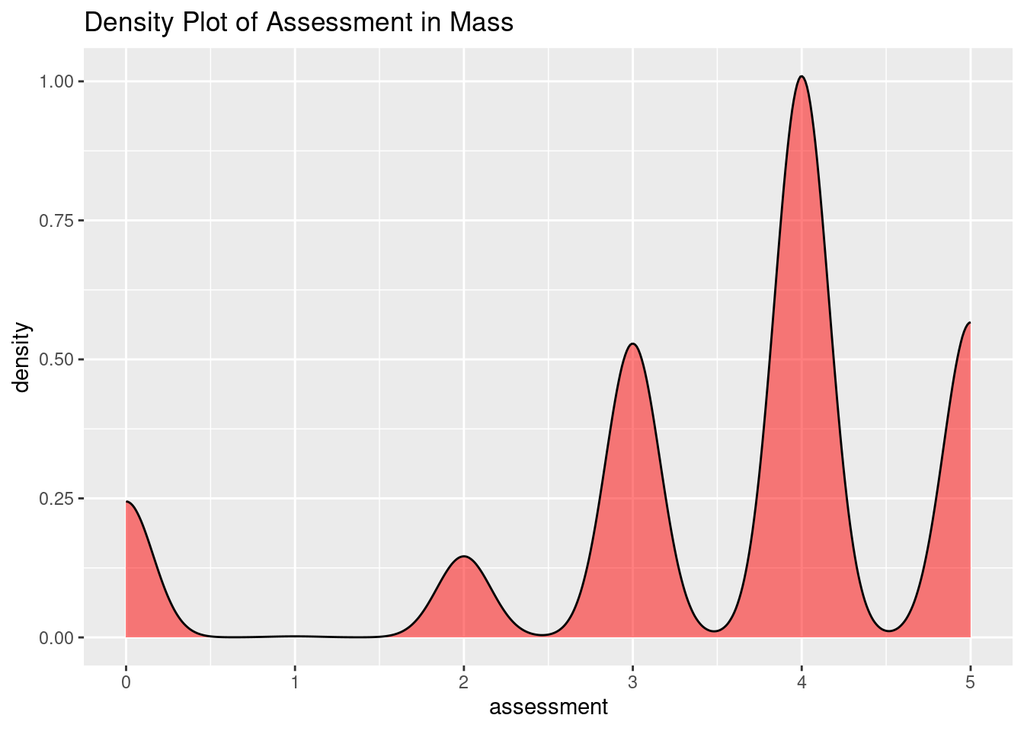

```r
ggplot(data = MassTrain_Clean, aes(x = assessment)) +
  geom_density(fill = "red", alpha = 0.5) +
  ggtitle("Density Plot of Assessment in Mass")
```

#7.Subtlety rating

```r
subtlety_Calc<- data.frame(table(CalcTrain_Clean$subtlety)) %>%
setNames(c("levels", "counts"))
subtlety_Calc
```

```
##   levels counts
## 1      1     95
## 2      2    242
## 3      3    502
## 4      4    346
## 5      5    361
```

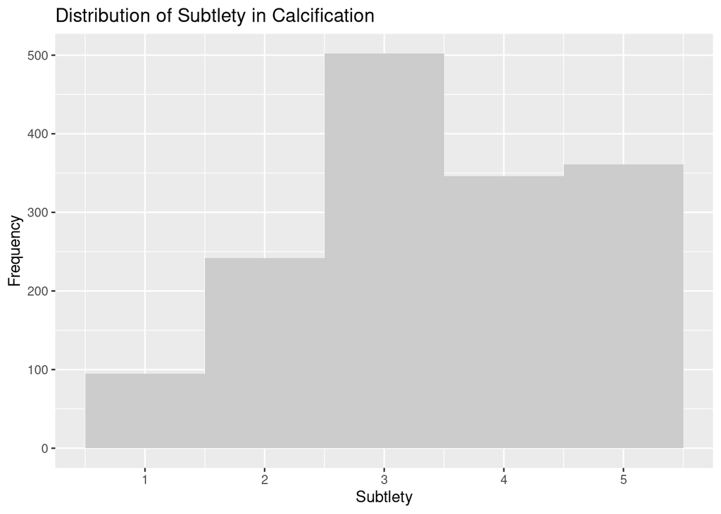

```r
ggplot(CalcTrain_Clean, aes(x = subtlety)) +
  geom_histogram(binwidth = 1, fill = "#cccccc") +
  labs(x = "Subtlety", y = "Frequency",
       title = "Distribution of Subtlety in Calcification")
```

#Subtlety rating in Mass

```r
Subtlety_Mass <- data.frame(table(MassTrain_Clean$subtlety)) %>%
setNames(c("levels", "counts"))
Subtlety_Mass
```

```
##   levels counts
## 1      0      2
## 2      1     41
## 3      2    100
## 4      3    257
## 5      4    375
## 6      5    543
```

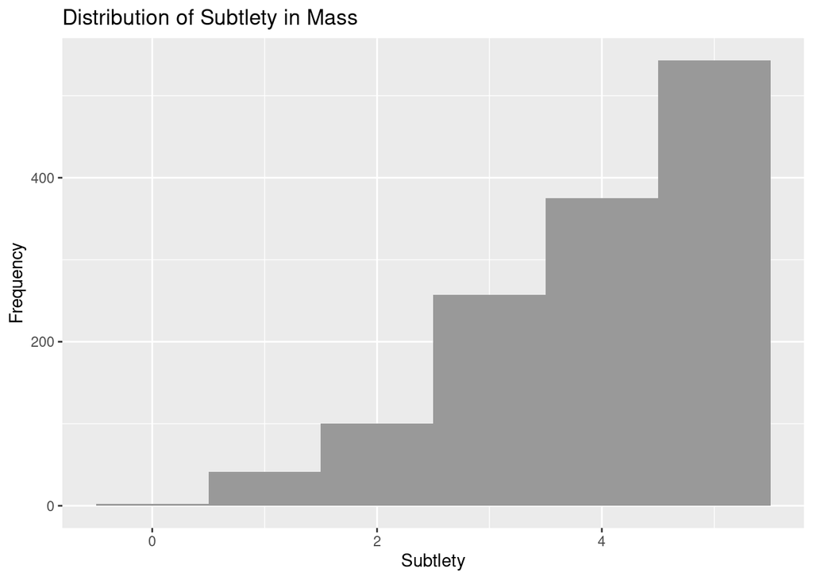

```r
ggplot(MassTrain_Clean, aes(x = subtlety)) +
  geom_histogram(binwidth = 1, fill = "#999999") +
  labs(x = "Subtlety", y = "Frequency",
       title = "Distribution of Subtlety in Mass ")
```

#8.Types of Pathalogy in Calcification

```r
table(CalcTrain_Clean$pathology)
```

```
##
##                  BENIGN BENIGN_WITHOUT_CALLBACK               MALIGNANT
##                     528                     474                     544
```

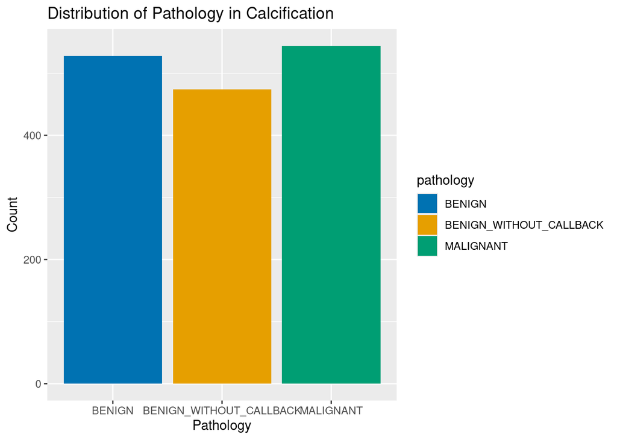

```r
ggplot(CalcTrain_Clean, aes(x = pathology, fill = pathology)) +
  geom_bar() +
  scale_fill_manual(values = c("#0072B2", "#E69F00", "#009E73")) +
  labs(title = "Distribution of Pathology in Calcification", x = "Pathology", y = "Count")
```

#Types of Pathalogy in Mass Case

```r
table(MassTrain_Clean$pathology)
```

```
##
##                  BENIGN BENIGN_WITHOUT_CALLBACK               MALIGNANT
##                     577                     104                     637
```

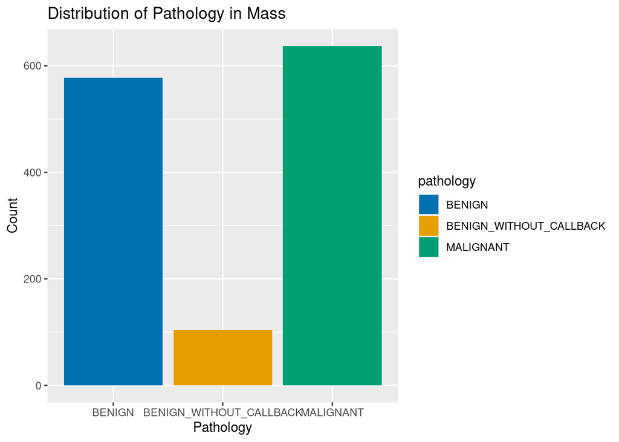

```r
ggplot(MassTrain_Clean, aes(x = pathology, fill = pathology)) +
  geom_bar() +
  scale_fill_manual(values = c("#0072B2", "#E69F00", "#009E73")) +
  labs(title = "Distribution of Pathology in Mass", x = "Pathology", y = "Count")
```

#9.Number of image views

```r
img_calc<- data.frame(table(CalcTrain_Clean$image_view)) %>%
  setNames(c("ImageView", "count"))
img_calc
```

```
##   ImageView count
## 1        CC   739
## 2       MLO   807
```

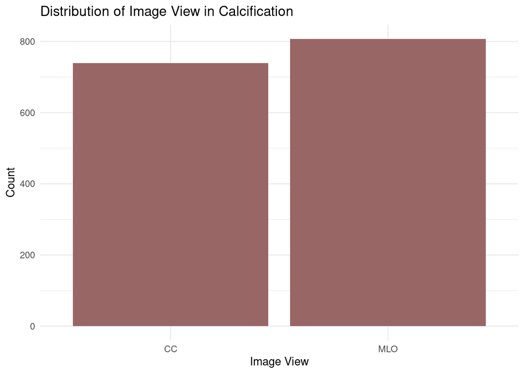

```r
ggplot(img_calc, aes(x = ImageView, y = count)) +
  geom_bar(stat = "identity", fill = "#996666") +
  labs(title = "Distribution of Image View in Calcification", x = "Image View", y = "Count") +
  theme_minimal()
```

#Number of image views in mass

```r
img_mass<- data.frame(table(MassTrain_Clean$image_view)) %>%
  setNames(c("ImageView", "count"))
img_mass
```

```
##   ImageView count
## 1        CC   607
## 2       MLO   711
```

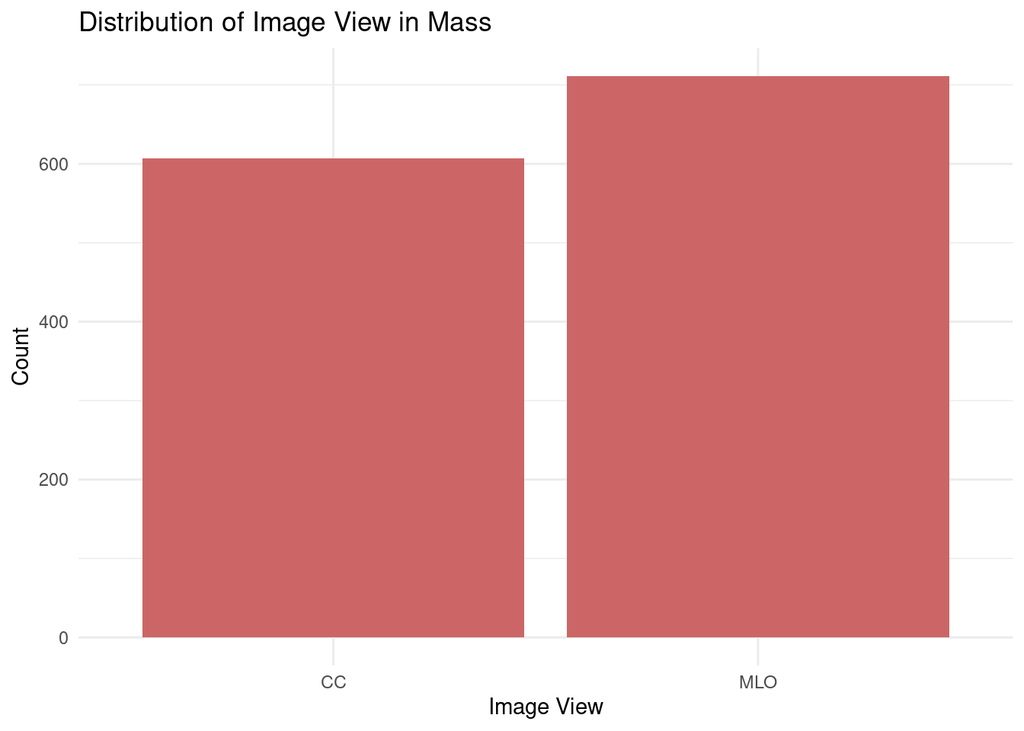

```r
ggplot(img_mass, aes(x = ImageView, y = count)) +
  geom_bar(stat = "identity", fill = "#CC6666") +
  labs(title = "Distribution of Image View in Mass", x = "Image View", y = "Count") +
  theme_minimal()
```

```r
#Correlation analysis
# Select only the numerical variables
numerical_vars <- CalcTrain_Clean %>%
  select_if(is.numeric)

# Perform correlation analysis
correlation_matrix <- cor(numerical_vars)

# Print the correlation matrix
print(correlation_matrix)
```

```
##                breast_density abnormality_id assessment   subtlety
## breast_density      1.0000000     -0.1185151  0.1772770 -0.2160527
## abnormality_id     -0.1185151      1.0000000 -0.2756986  0.2288412
## assessment          0.1772770     -0.2756986  1.0000000 -0.1336970
## subtlety           -0.2160527      0.2288412 -0.1336970  1.0000000
```

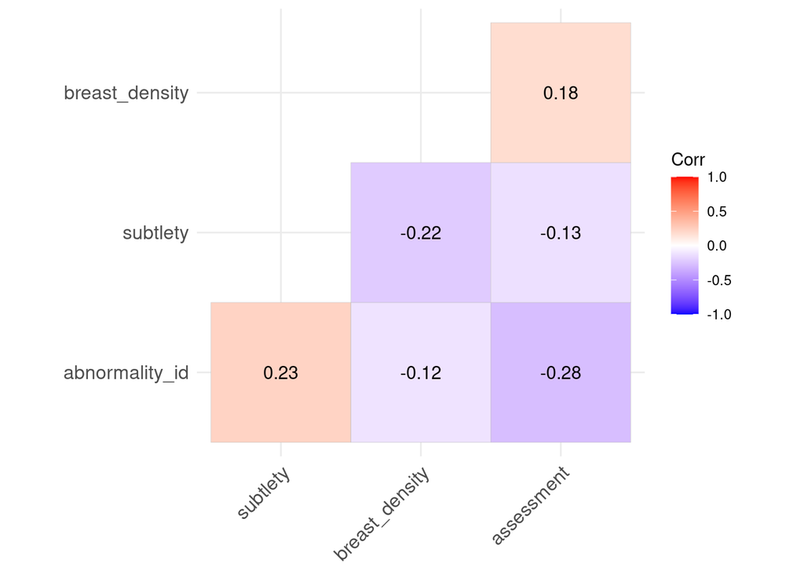

```r
cor_matrix <- cor(CalcTrain_Clean[, c("breast_density", "abnormality_id", "assessment", "subtlety")])

ggcorrplot(cor_matrix,
           hc.order = TRUE,
           type = "lower",
           lab = TRUE)
```

#To predict pathology feature against other features in Calcification

```r
set.seed(101)
```

```r
features <- c("breast_density", "left_or_right_breast", "image_view",
              "abnormality_type", "calc_type", "calc_distribution",
              "assessment", "subtlety")
target <- "pathology"
```

```r
train_data <- CalcTrain_Clean[, c(features, target)]
test_data <- CalcTest_Clean[, c(features, target)]
```

#Train the classification algorithm using the randomForest() function

```r
Calc_rf <- randomForest(pathology ~ ., data = train_data)
Calc_rf
```

```
##
## Call:
##  randomForest(formula = pathology ~ ., data = train_data)
##                Type of random forest: classification
##                      Number of trees: 500
## No. of variables tried at each split: 2
##
##         OOB estimate of  error rate: 20.18%
## Confusion matrix:
##                         BENIGN BENIGN_WITHOUT_CALLBACK MALIGNANT class.error
## BENIGN                     464                       8        56  0.12121212
## BENIGN_WITHOUT_CALLBACK      7                     467         0  0.01476793
## MALIGNANT                  241                       0       303  0.44301471
```

#Converting categorical variables to factors with the same levels in train and test datasets

```r
for (var in features) {
  if (is.factor(train_data[[var]])) {
    levels(test_data[[var]]) <- levels(train_data[[var]])
    levels(train_data[[var]]) <- levels(test_data[[var]])
  }
}
```

```r
Calc_pred <- predict(Calc_rf, data = test_data)
```

```r
cm <- confusionMatrix(Calc_pred, train_data$pathology)
cm
```

```
## Confusion Matrix and Statistics
##
##                          Reference
## Prediction                BENIGN BENIGN_WITHOUT_CALLBACK MALIGNANT
##   BENIGN                     464                       7       241
##   BENIGN_WITHOUT_CALLBACK      8                     467         0
##   MALIGNANT                   56                       0       303
##
## Overall Statistics
##
##                Accuracy : 0.7982
##                  95% CI : (0.7773, 0.8179)
##     No Information Rate : 0.3519
##     P-Value [Acc > NIR] : < 2.2e-16
##
##                   Kappa : 0.6973
##
##  Mcnemar's Test P-Value : NA
##
## Statistics by Class:
##
##                      Class: BENIGN Class: BENIGN_WITHOUT_CALLBACK
## Sensitivity                 0.8788                         0.9852
## Specificity                 0.7564                         0.9925
## Pos Pred Value              0.6517                         0.9832
## Neg Pred Value              0.9233                         0.9935
## Prevalence                  0.3415                         0.3066
## Detection Rate              0.3001                         0.3021
## Detection Prevalence        0.4605                         0.3072
## Balanced Accuracy           0.8176                         0.9889
##                      Class: MALIGNANT
## Sensitivity                    0.5570
## Specificity                    0.9441
## Pos Pred Value                 0.8440
## Neg Pred Value                 0.7970
## Prevalence                     0.3519
## Detection Rate                 0.1960
## Detection Prevalence           0.2322
## Balanced Accuracy              0.7505
```

```r
accuracy <- cm$overall['Accuracy']
print(accuracy)
```

```
##  Accuracy
## 0.7981889
```

#Variable Importance

```r
importance <-  importance(Calc_rf)
print(importance)
```

```
##                      MeanDecreaseGini
## breast_density              30.881460
## left_or_right_breast        10.678685
## image_view                   5.354515
## abnormality_type             0.000000
## calc_type                  208.162086
## calc_distribution           56.003927
## assessment                 313.932641
## subtlety                    55.339799
```

```r
varImportance <- data.frame(Variables = row.names(importance))
rankImportance <- varImportance%>%mutate(Rank=paste(dense_rank(desc(importance))))
```

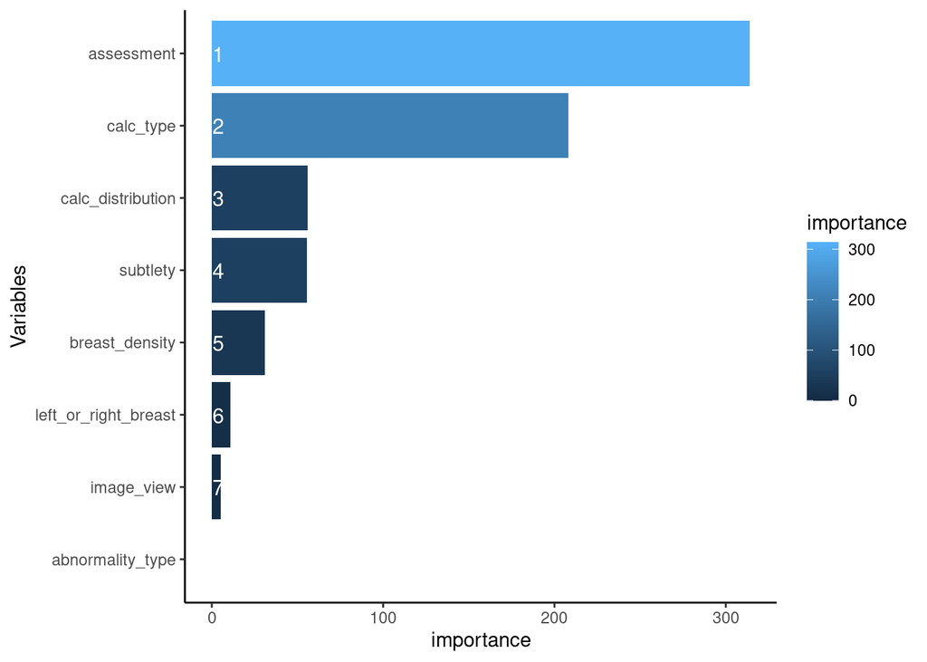

```r
ggplot(rankImportance,aes(x=reorder(Variables,importance),
 y=importance,fill=importance))+
 geom_bar(stat="identity") +
 geom_text(aes(x = Variables, y = 0.5, label = Rank),
 hjust=0, vjust=0.55, size = 4, colour = "white") +
 labs(x = "Variables") +
 coord_flip() +
 theme_classic()
```

#plot the number of nodes for trees

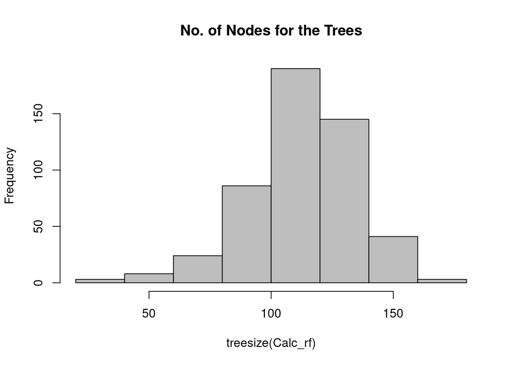

```r
hist(treesize(Calc_rf),
     main = "No. of Nodes for the Trees",
     col = "grey")
```

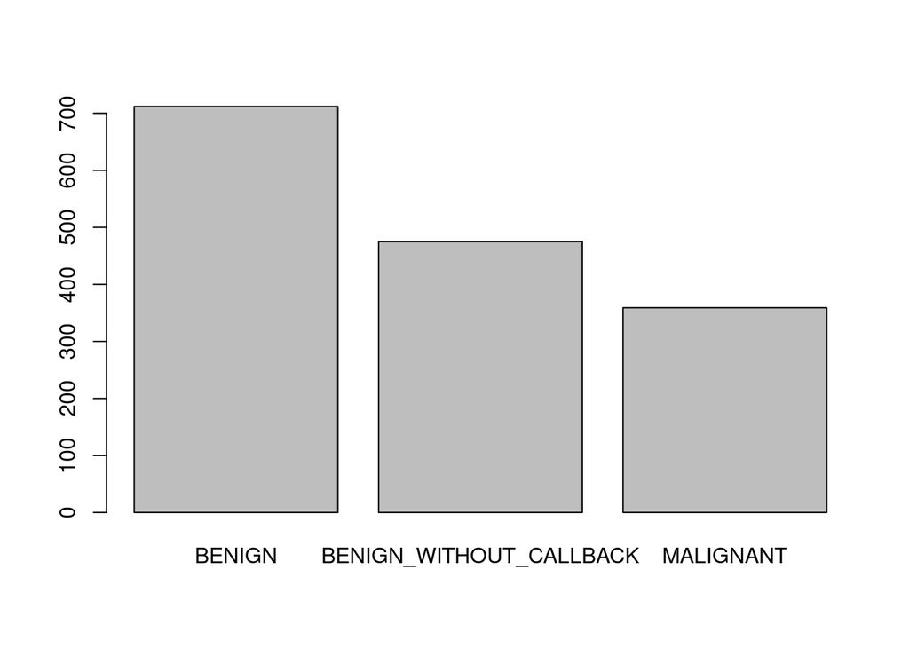

```r
plot(Calc_pred)
```